# PES University, Bangalore Established under the Karnataka Act No. 16 of 2013

UE20CS312 - Data Analytics** **Worksheet 1a - Part 2: EDA with R | ANOVA

Ishita Bharadwaj, Dept. of CSE - PES1UG20CS648

Collaborated with Hita - PES1UG20CS645

# Part I. Exploratory Data Analysis with R

```r
library(tidyverse)
cbc_df <- read_csv('CharlesBookClubDataset.csv')
head(cbc_df)
```

```
## # A tibble: 6 × 26
##    ...1 `Seq#` `ID#` Gender     M     R     F FirstPurch ChildBks YouthBks
##   <dbl>  <dbl> <dbl>  <dbl> <dbl> <dbl> <dbl>      <dbl>    <dbl>    <dbl>
## 1     0      1    25      1   297    14     2         22        0        1
## 2     1      2    29      0   128     8     2         10        0        0
## 3     2      3    46      1   138    22     7         56        2        1
## 4     3      4    47      1   228     2     1          2        0        0
## 5     4      5    51      1   257    10     1         10        0        0
## 6     5      6    60      1   145     6     2         12        0        0
## # … with 16 more variables: CookBks <dbl>, DoItYBks <dbl>, RefBks <dbl>,
## #   ArtBks <dbl>, GeogBks <dbl>, ItalCook <dbl>, ItalAtlas <dbl>,
## #   ItalArt <dbl>, Florence <dbl>, `Related Purchase` <dbl>,
## #   Yes_Florence <dbl>, No_Florence <dbl>, Name <chr>, Phone_No. <chr>,
## #   Address <chr>, Job <chr>
```

## Solutions

### Solution 1

Generate an understanding of the dataset via a summary of its features. Find the count, missing count, minimum, 1st quartile, median, mean, 3rd quartile, max and standard deviation of all relevant columns. Separately, print the total number of missing values in each column.

Summary stats for all columns.

```r
summary(cbc_df)
```

```
##       ...1             Seq#           ID#            Gender
##  Min.   :   0.0   Min.   :   1   Min.   :   25   Min.   :0.0000
##  1st Qu.: 999.8   1st Qu.:1001   1st Qu.: 8253   1st Qu.:0.0000
##  Median :1999.5   Median :2000   Median :16581   Median :1.0000
##  Mean   :1999.5   Mean   :2000   Mean   :16595   Mean   :0.7045
##  3rd Qu.:2999.2   3rd Qu.:3000   3rd Qu.:24838   3rd Qu.:1.0000
##  Max.   :3999.0   Max.   :4000   Max.   :32977   Max.   :1.0000
##
##        M               R               F            FirstPurch
##  Min.   : 15.0   Min.   : 2.00   Min.   : 1.000   Min.   : 2.00
##  1st Qu.:130.0   1st Qu.: 8.00   1st Qu.: 1.000   1st Qu.:12.00
##  Median :208.0   Median :12.00   Median : 2.000   Median :20.00
##  Mean   :208.2   Mean   :13.43   Mean   : 3.831   Mean   :26.51
##  3rd Qu.:283.0   3rd Qu.:16.00   3rd Qu.: 6.000   3rd Qu.:36.00
##  Max.   :479.0   Max.   :36.00   Max.   :12.000   Max.   :99.00
##  NA's   :93      NA's   :342     NA's   :218
##     ChildBks         YouthBks         CookBks          DoItYBks
##  Min.   :0.0000   Min.   :0.0000   Min.   :0.0000   Min.   :0.0000
##  1st Qu.:0.0000   1st Qu.:0.0000   1st Qu.:0.0000   1st Qu.:0.0000
##  Median :0.0000   Median :0.0000   Median :0.0000   Median :0.0000
##  Mean   :0.6398   Mean   :0.3048   Mean   :0.7312   Mean   :0.3508
##  3rd Qu.:1.0000   3rd Qu.:0.0000   3rd Qu.:1.0000   3rd Qu.:1.0000
##  Max.   :7.0000   Max.   :5.0000   Max.   :7.0000   Max.   :5.0000
##
##      RefBks           ArtBks         GeogBks          ItalCook
##  Min.   :0.0000   Min.   :0.000   Min.   :0.0000   Min.   :0.0000
##  1st Qu.:0.0000   1st Qu.:0.000   1st Qu.:0.0000   1st Qu.:0.0000
##  Median :0.0000   Median :0.000   Median :0.0000   Median :0.0000
##  Mean   :0.2562   Mean   :0.289   Mean   :0.3875   Mean   :0.1252
##  3rd Qu.:0.0000   3rd Qu.:0.000   3rd Qu.:1.0000   3rd Qu.:0.0000
##  Max.   :4.0000   Max.   :5.000   Max.   :6.0000   Max.   :3.0000
##
##    ItalAtlas         ItalArt           Florence      Related Purchase
##  Min.   :0.0000   Min.   :0.00000   Min.   :0.0000   Min.   :0.000
##  1st Qu.:0.0000   1st Qu.:0.00000   1st Qu.:0.0000   1st Qu.:0.000
##  Median :0.0000   Median :0.00000   Median :0.0000   Median :0.000
##  Mean   :0.0375   Mean   :0.04575   Mean   :0.0845   Mean   :0.885
##  3rd Qu.:0.0000   3rd Qu.:0.00000   3rd Qu.:0.0000   3rd Qu.:1.000
##  Max.   :2.0000   Max.   :2.00000   Max.   :1.0000   Max.   :8.000
##
##   Yes_Florence     No_Florence         Name            Phone_No.
##  Min.   :0.0000   Min.   :0.0000   Length:4000        Length:4000
##  1st Qu.:0.0000   1st Qu.:1.0000   Class :character   Class :character
##  Median :0.0000   Median :1.0000   Mode  :character   Mode  :character
##  Mean   :0.0845   Mean   :0.9155
##  3rd Qu.:0.0000   3rd Qu.:1.0000
##  Max.   :1.0000   Max.   :1.0000
##
##    Address              Job
##  Length:4000        Length:4000
##  Class :character   Class :character
##  Mode  :character   Mode  :character
##
##
##
##
```

Std. Deviation for 22 numeric columns. Notice that col names - M, R, F have missing values. so std dev is NA.

```r
# columns name, ph. no., address, job are non-numeric, so a subset of df is taken for standard deviation (excluding these 4 columns.)
nums <- unlist(lapply(cbc_df, is.numeric), use.names = FALSE)
colnames(cbc_df[ , nums])
```

```
##  [1] "...1"             "Seq#"             "ID#"              "Gender"
##  [5] "M"                "R"                "F"                "FirstPurch"
##  [9] "ChildBks"         "YouthBks"         "CookBks"          "DoItYBks"
## [13] "RefBks"           "ArtBks"           "GeogBks"          "ItalCook"
## [17] "ItalAtlas"        "ItalArt"          "Florence"         "Related Purchase"
## [21] "Yes_Florence"     "No_Florence"
```

```r
df<-cbc_df[ , nums]
apply(df,2,sd)
```

```
##             ...1             Seq#              ID#           Gender
##     1154.8448669     1154.8448669     9484.4337921        0.4563242
##                M                R                F       FirstPurch
##               NA               NA               NA       18.3513798
##         ChildBks         YouthBks          CookBks         DoItYBks
##        0.9943426        0.6119404        1.0894128        0.6879991
##           RefBks           ArtBks          GeogBks         ItalCook
##        0.5582686        0.6008904        0.7506561        0.3854862
##        ItalAtlas          ItalArt         Florence Related Purchase
##        0.2147214        0.2206108        0.2781710        1.2262344
##     Yes_Florence      No_Florence
##        0.2781710        0.2781710
```

Total number of missing values in each column.

```r
colSums(is.na(cbc_df))
```

```
##             ...1             Seq#              ID#           Gender
##                0                0                0                0
##                M                R                F       FirstPurch
##               93              342              218                0
##         ChildBks         YouthBks          CookBks         DoItYBks
##                0                0                0                0
##           RefBks           ArtBks          GeogBks         ItalCook
##                0                0                0                0
##        ItalAtlas          ItalArt         Florence Related Purchase
##                0                0                0                0
##     Yes_Florence      No_Florence             Name        Phone_No.
##                0                0                0                0
##          Address              Job
##                0                0
```

### Solution 2

Replace missing values within the Recency, Frequency, and Monetary features with suitable values. Explain your reasoning behind the method of substitution used. *Hint:* Try plotting the distribution of the values in each feature using the `hist` function. Think about how to best deal with data imputation. Also, plot the distribution of feature values after imputation.

```r
r<-cbc_df[cbc_df$R == 0, ]
m<-cbc_df[cbc_df$M == 0, ]
f<-cbc_df[cbc_df$F == 0, ]
#Monetary
print(nrow(m))
```

```
## [1] 93
```

```r
#Frequency
print(nrow(f))
```

```
## [1] 218
```

```r
#Recency
print(nrow(r))
```

```
## [1] 342
```

Histograms

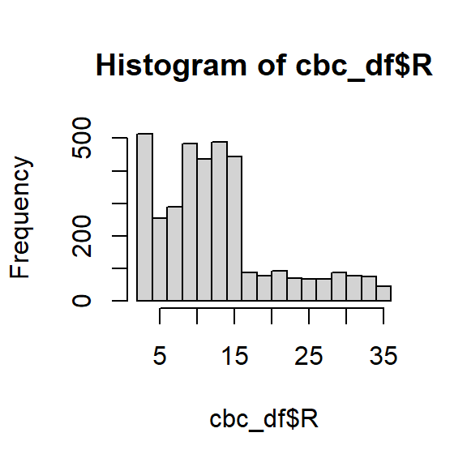

```r
getmode <- function(v) {
   uniqv <- unique(v)
   uniqv[which.max(tabulate(match(v, uniqv)))]
}


hist(cbc_df$R)
```

```r
result.mean <-  mean(cbc_df$R,na.rm = TRUE)
print(result.mean)
```

```
## [1] 13.43412
```

```r
result.median <-  median(cbc_df$R,na.rm = TRUE)
print(result.median)
```

```
## [1] 12
```

```r
getmode(cbc_df$R)
```

```
## [1] 14
```

```r
cbc_df["R"][is.na(cbc_df["R"])] <- result.median
```

There’s very less difference between median and mean. We will replace missing values with median(for columns M and R) rather than the mean because it isn’t influenced by large values.

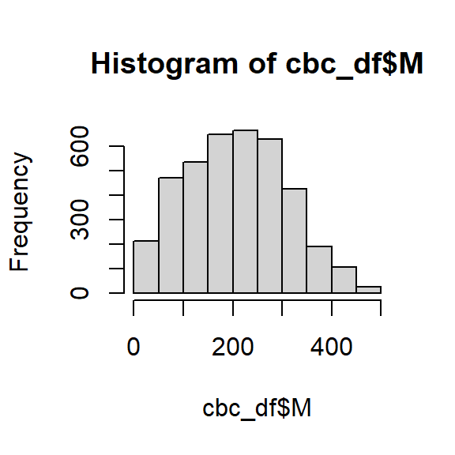

```r
hist(cbc_df$M)
```

```r
result.mean <-  mean(cbc_df$M,na.rm = TRUE)
print(result.mean)
```

```
## [1] 208.2089
```

```r
result.median <-  median(cbc_df$M,na.rm = TRUE)
print(result.median)
```

```
## [1] 208
```

```r
cbc_df["M"][is.na(cbc_df["M"])] <- result.median
```

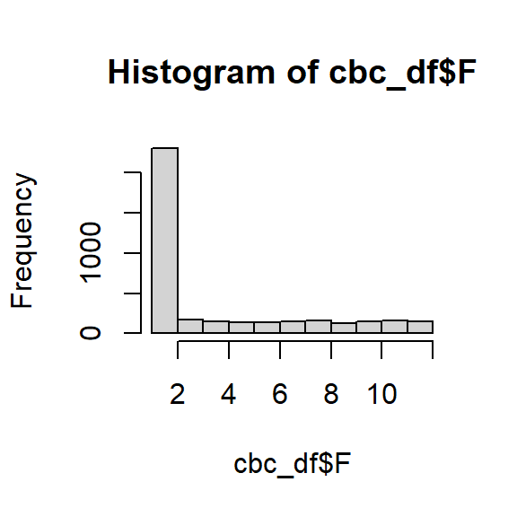

```r
hist(cbc_df$F)
```

```r
result.mean <-  mean(cbc_df$F,na.rm = TRUE)
print(result.mean)
```

```
## [1] 3.831042
```

```r
result.median <-  median(cbc_df$F,na.rm = TRUE)
print(result.median)
```

```
## [1] 2
```

```r
getmode(cbc_df$F)
```

```
## [1] 1
```

```r
cbc_df["F"][is.na(cbc_df["F"])] <- getmode(cbc_df$F)

colSums(is.na(cbc_df))
```

```
##             ...1             Seq#              ID#           Gender
##                0                0                0                0
##                M                R                F       FirstPurch
##                0                0                0                0
##         ChildBks         YouthBks          CookBks         DoItYBks
##                0                0                0                0
##           RefBks           ArtBks          GeogBks         ItalCook
##                0                0                0                0
##        ItalAtlas          ItalArt         Florence Related Purchase
##                0                0                0                0
##     Yes_Florence      No_Florence             Name        Phone_No.
##                0                0                0                0
##          Address              Job
##                0                0
```

```r
# All columns missing value have been replaced by the optimal central tendency.
```

### Solution 3

Discretize the continuous values of Monetary, Recency, and Frequency into appropriate bins, and create three new columns `Mcode`, `Rcode` and `Fcode` respectively, for the discretized values. Explicitly mention the number of bins used and explain the choice for the bin size. Print out the summary of the newly created columns. *Hint:* Use the `cut` function to break on preset breakpoints. What are the most optimum breakpoints you can choose? Try to think of a statistical function that provides these breakpoints for optimum binning.

```r
#' bins_fd
#' @description returns number of bins according to the freedman diaconis rule
#' @param vec numeric vector
#' @return number of bins
bins_fd <- function(vec){ceiling(diff(range(vec))/ (2*IQR(vec)/ length(vec)^(1/3)))}
```

```r
cbc_df2<- cbc_df[c("M","R","F")]
#printing number of bins for M, R, F repectively
cat("No. of bins for M: ",bins_fd(cbc_df2$M),"\n")
```

```
## No. of bins for M:  25
```

```r
cat("No. of bins for R: ",bins_fd(cbc_df2$R),"\n")
```

```
## No. of bins for R:  34
```

```r
cat("No. of bins for F: ",bins_fd(cbc_df2$F),"\n")
```

```
## No. of bins for F:  18
```

```r
cbc_df2$Mcode <- cut(cbc_df2$M, breaks= bins_fd(cbc_df2$M))
cbc_df2$Rcode <- cut(cbc_df2$R, breaks= bins_fd(cbc_df2$R))
cbc_df2$Fcode <- cut(cbc_df2$F, breaks= bins_fd(cbc_df2$F))
head(cbc_df2)
```

```
## # A tibble: 6 × 6
##       M     R     F Mcode     Rcode    Fcode
##   <dbl> <dbl> <dbl> <fct>     <fct>    <fct>
## 1   297    14     2 (293,312] (13,14]  (1.61,2.22]
## 2   128     8     2 (126,145] (7,8]    (1.61,2.22]
## 3   138    22     7 (126,145] (21,22]  (6.5,7.11]
## 4   228     2     1 (219,238] (1.97,3] (0.989,1.61]
## 5   257    10     1 (256,275] (9,10]   (0.989,1.61]
## 6   145     6     2 (145,163] (5,6]    (1.61,2.22]
```

### Solution 4

The marketing team heavily relies on the RFM variables of the recency of last purchase, total number of purchases, and total money spent on purchases to gauge the health of the members of the book club. Increases in either the frequency of purchases or monetary spend and decreases in time since last purchase across the customer base, will intuitively lead to more sales for the business.

#### 4.1 Bar Graphs

Create and visualize histograms for the discretized Recency, Frequency, Monetary features. Also create one for the `FirstPurch` feature.

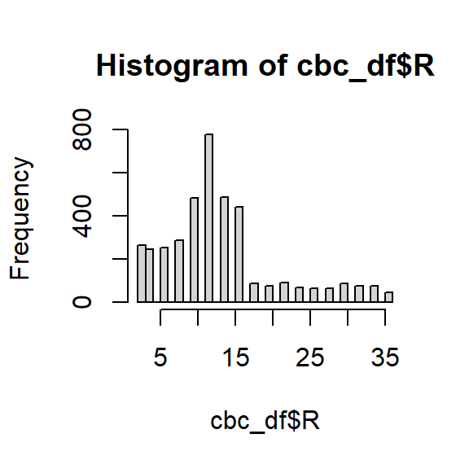

```r
hist(cbc_df$R, breaks = bins_fd(cbc_df2$R))
```

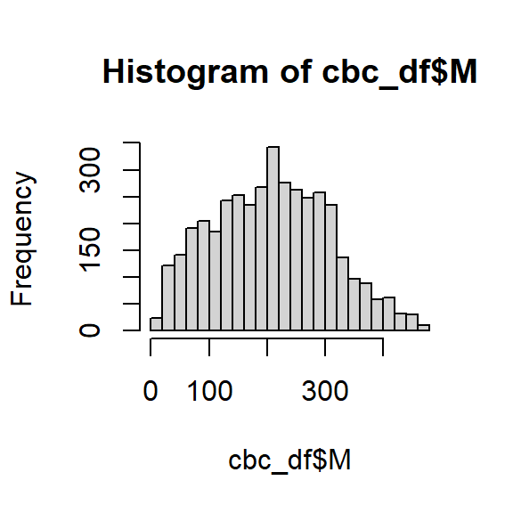

```r
hist(cbc_df$M, breaks = bins_fd(cbc_df2$M))
```

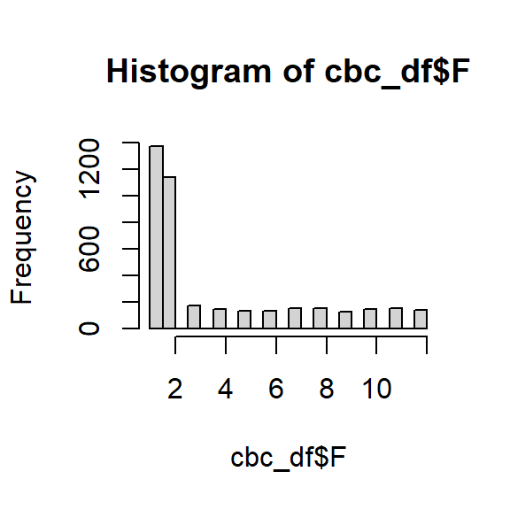

```r
hist(cbc_df$F, breaks = bins_fd(cbc_df2$F))
```

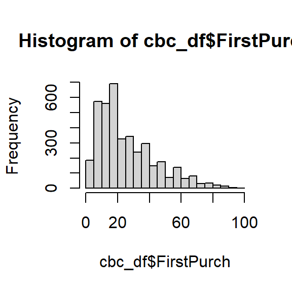

```r
hist(cbc_df$FirstPurch, breaks = bins_fd(cbc_df$FirstPurch))
```

#### 4.2 Box Plot

Transform the `Florence` variable into a categorical feature that can take up the values `True` or `False`. Create and visualize horizontal box plots for the original Recency, Frequence, Monetary and `FirstPurch` features against the `Florence` variable. *Hint:* To transform `Florence`, use the concept of factors in R and set the labels `True` and `False`.

```r
new <- cbc_df$Florence
cbc_df$Florence <- as.logical(as.numeric(new))
cbc_df
```

```
## # A tibble: 4,000 × 26
##     ...1 `Seq#` `ID#` Gender     M     R     F FirstPurch ChildBks YouthBks
##    <dbl>  <dbl> <dbl>  <dbl> <dbl> <dbl> <dbl>      <dbl>    <dbl>    <dbl>
##  1     0      1    25      1   297    14     2         22        0        1
##  2     1      2    29      0   128     8     2         10        0        0
##  3     2      3    46      1   138    22     7         56        2        1
##  4     3      4    47      1   228     2     1          2        0        0
##  5     4      5    51      1   257    10     1         10        0        0
##  6     5      6    60      1   145     6     2         12        0        0
##  7     6      7    61      1   190    16     1         16        0        0
##  8     7      8    79      1   187    12     1         14        1        0
##  9     8      9    81      1   252    10     1         10        0        0
## 10     9     10    90      1   240     6     3         20        0        0
## # … with 3,990 more rows, and 16 more variables: CookBks <dbl>, DoItYBks <dbl>,
## #   RefBks <dbl>, ArtBks <dbl>, GeogBks <dbl>, ItalCook <dbl>, ItalAtlas <dbl>,
## #   ItalArt <dbl>, Florence <lgl>, `Related Purchase` <dbl>,
## #   Yes_Florence <dbl>, No_Florence <dbl>, Name <chr>, Phone_No. <chr>,
## #   Address <chr>, Job <chr>
```

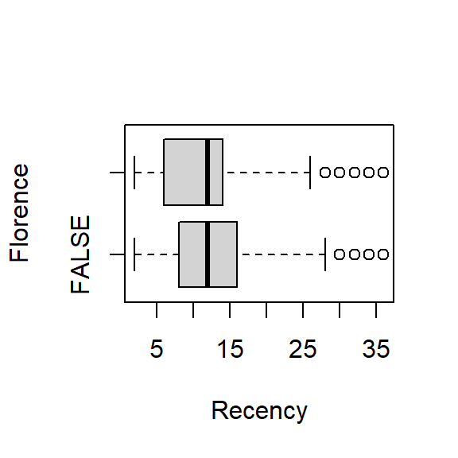

```r
boxplot(R ~ Florence, data = cbc_df, xlab = "Recency",
   ylab = "Florence",horizontal=TRUE)
```

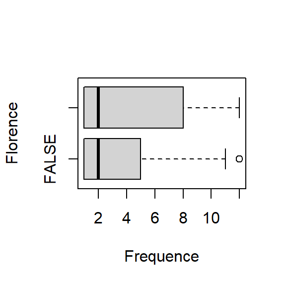

```r
boxplot(F ~ Florence, data = cbc_df, xlab = "Frequence",
   ylab = "Florence",horizontal=TRUE)
```

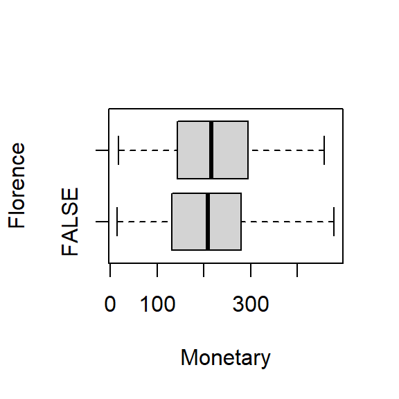

```r
boxplot(M ~ Florence, data = cbc_df, xlab = "Monetary",
   ylab = "Florence",horizontal=TRUE)
```

#### 4.3 Density Plot

Create and visualize a density plot for Recency, Frequency, Monetary and `FirstPurch` features.

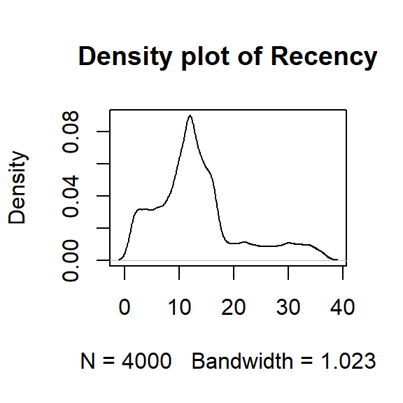

```r
r<-density(cbc_df$R)
plot(r,main='Density plot of Recency')
```

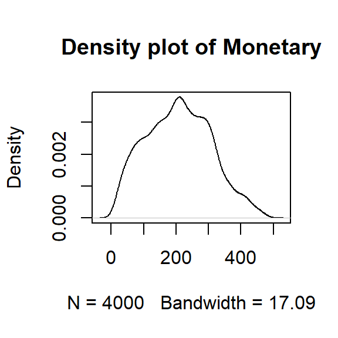

```r
m<-density(cbc_df$M)
plot(m,main='Density plot of Monetary')
```

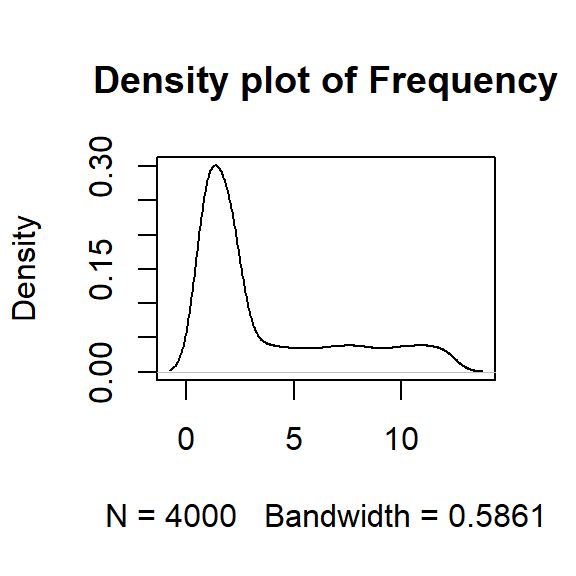

```r
f<-density(cbc_df$F)
plot(f,main='Density plot of Frequency')
```

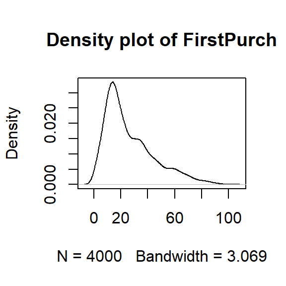

```r
p<-density(cbc_df$FirstPurch)
plot(p,main='Density plot of FirstPurch')
```